# Типы древесной растительности (по данным БПЛА)

map

UAV

Agisoft Metashape

Multispectral

Картографирование древесной растительности Дилижанского нацпарка по данным зимней съемки с БПЛА.

Published

February 25, 2025

Кратко. В рамках экспедиции НСО кафедры картографии и геоинформатики Географического факультета МГУ имени М.В. Ломоносова проводилась апробация методик высокоуровневой тематической обработки пространственных данных, полученных с БПЛА. На основе этих материалов была составлена подробная карта типов древесной растительности.

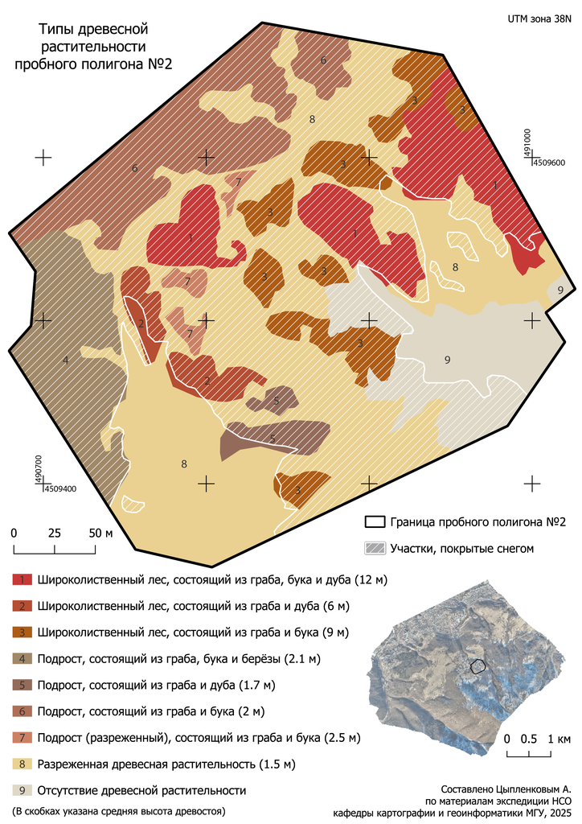

📄 Скачать карту (PDF)

Исследуемая территория расположена в Дилижанском национальном парке на северо-востоке Армянского нагорья. Рельеф характеризуется сильной расчлененностью, наличием глубоких ущелий и крутых склонов с перепадами высот от 1100 до 2800 метров над уровнем моря. В лесном ярусе преобладают листопадные породы: бук восточный, дуб грузинский, а также граб обыкновенный и восточный.

Съёмка растительности осуществлялась в зимний период с использованием нескольких моделей БПЛА, оснащенных мультиспектральными и тепловизионными камерами. Для обработки снимков и построения плотных облаков точек использовалось программное обеспечение Agisoft Metashape. Зимняя съемка показала существенные преимущества: наличие снежного покрова обеспечило высокий контраст для дешифрирования отдельных деревьев и подроста. Кроме того, тепловизионная съемка позволила различать породы деревьев, так как дубы на снимках выделялись более высокой температурой по сравнению с грабами и березами.

В результате была составлена карта типов древесной растительности для пробного полигона №2. На карте детально пространственно разделены участки широколиственного леса различного состава (граб, бук, дуб) и участки подроста. Для каждого выделенного класса в легенде указана средняя высота древостоя, которая составляет до 12 метров для спелых лесов и варьируется от 1.7 до 2.5 метров для подроста. Также на карте специальной штриховкой обозначены территории, покрытые снегом в момент проведения съёмок.

**Использованное ПО**: Agisoft Metashape, QGIS, Adobe Illustrator

**Роль**: Соавтор исследования, автор карты